# Comparison of Hierarchical Parent Proportion Tests

Adam Chan

20 October, 2021

# 1 Data Loading

The following datasets were used in this analysis:

Flow Cytometry:

- AML, FlowCAP-II 2013  
  55711535 cells from 359 samples Predicting aml/normal patients
- COVID-19 PBMC, Humblet-Baron 2020  
  6510011 cells from 49 patients (6 health, 23 mild-to-moderate, 20 severe) samples Predicting mild vs severe COVID-19 through PBMC immune profile
- COVID-19 CD4 & CD8 T Cells, De Biasi 2020  
  Subset of 5000 cells from 12 Healthy controls and 19 covid patients
- COVID-19 CD8 Non Naive, Mathew 2020  
  54 healthy donors and 114 covid patients. Analysed 60% of the original cells which amounted to 11,591,741. Predicting between recovered donors and healthy donors
- MS HSCT, Ma 2020  
  Predicting between relapse and non-relapse patients recovering from stem cell transplant

scRNA-seq: - Melanoma, Sade-Feldman 2019

```r
#' Parent proportion test scripts
#' This script is to summarise results from the treeParentProportionTest.R Scripts

suppressPackageStartupMessages({
  library(ggplot2)
  library(dplyr)
  library(tidyr)
  library(gridExtra)
  library(latex2exp)
})

treeSigFiles <- list.files("data/benchmarking_data/significance",
                                     full.names = TRUE)

load(file = treeSigFiles[1])

tree_sig_df_combined <- tree_sig_df

for (i in 2:length(treeSigFiles)){
  load(file = treeSigFiles[i])

  tree_sig_df_combined <- tree_sig_df_combined %>%
    bind_rows(tree_sig_df)
}

#' ======================================================================
#' Comparison Visualisations
#' ----------------------------------------------------------------------

gg_theme <- theme_bw() +
  theme(panel.border = element_blank(),
        axis.line = element_line(color = 'black'))

cbp1 <- c("#e69f00", "#56b4e9", "#009e73", "#f0e442",
          "#cc79a7", "#0072b2", "#d55e00", "#999999",
          "#f27c7c", "#279a98", "#9a3f44", "#a53093",
          "#4c5e66")
```

# 2 Visualisations

## 2.1 Comparing proportion relative to parent vs relative to all

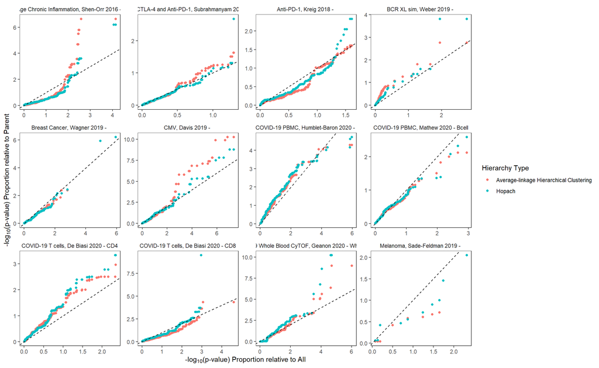

```r
#' Q-Q plots by ordering parent vs all
qq_df <- tree_sig_df_combined %>%
  dplyr::filter(statAll != 0) %>%
  mutate(neglogp_all = -log(pvalAll, base=10)) %>%
  arrange(dataset, hierarchy, neglogp_all) %>%
  group_by(dataset, hierarchy) %>%
  mutate(row_id = 1:n()) %>%
  select(dataset,hierarchy, row_id, neglogp_all) %>%
  left_join(
    (tree_sig_df_combined %>%
      dplyr::filter(statAll != 0) %>%
      mutate(neglogp_parent = -log(pvalParent, base=10)) %>%
      arrange(dataset, hierarchy, neglogp_parent) %>%
      group_by(dataset, hierarchy) %>%
      mutate(row_id = 1:n()) %>%
      select(dataset,hierarchy, row_id, neglogp_parent)),
    by=c("dataset"="dataset", "hierarchy"="hierarchy", "row_id"="row_id")
    )

ggplot(qq_df %>%
         dplyr::filter(hierarchy %in% c("average", "hopach") &
                  !(dataset %in% c("COVID-19 PBMC, Mathew 2020 - CD8nonNaive",
                                   "COVID-19 PBMC, Humblet-Baron 2020",
                                   "COVID-19 T cells, De Biasi 2020 - CD8 - home_hosp",
                                   "Anti-CTLA-4 and Anti-PD-1, Subrahmanyam 2018 - PD1 - home_hosp"))) %>%
         mutate(hierarchy = case_when(
           hierarchy == "average" ~ "Average-linkage Hierarchical Clustering",
           hierarchy == "hopach" ~ "Hopach",
           TRUE ~ hierarchy
         ))) +
  geom_point(aes(x=neglogp_all, y=neglogp_parent, color=hierarchy),
             size=1.5) +
  # geom_line(aes(x=neglogp_all, y=neglogp_parent, color=hierarchy))+
  geom_abline(slope=1, intercept=0, linetype="dashed") +
  facet_wrap(~dataset, scales="free", ncol=4) +
  theme_bw() +
  theme(strip.background = element_blank(),
        panel.grid.major = element_blank(),
        panel.grid.minor = element_blank()) +
  labs(x=TeX("-log_{10}(p-value) Proportion relative to All"),
       y=TeX("-log_{10}(p-value) Proportion relative to Parent"),
       col="Hierarchy Type") # Exported as 8 x 13 for paper
```